# Final Beneficial Arthropod Diversity Report

## This is a second report of the beneficial predatory arthropods (insects, spiders, centipedes) that we found on your farm during our research in Summer 2017.

### A summary of our study:

#### We collected insects, spiders, centipedes, and other beneficial ground crawling predators on farms in southeastern Pennsylvania to understand how urbanization affects the health of ecosystems on farms. We used data on land use around each of the farms to classify farms into three urban intensity categories. Urban Intensity is measured by the amount of land around each farm that is developed by structures such as parking lots, roads, buildings, sidewalks, and other surfaces not penetrable by water.

#### Based on our calculations of the urban landscape around your farm, your farm’s Urban Intensity category is **Medium Intensity**.

#### Additionally, we surveyed plant species and ground cover in a 40 sq foot area surrounding each arthropod trap. We estimated how much of that surrounding area was taken up by crops, weeds, dirt, and plastic mulch. Below, we describe how these factors affect the arthropod community.

### The **richness (number of types)** of arthropods found on farms compared with the area of weedy plant coverage, separated by Urban Intensity category:

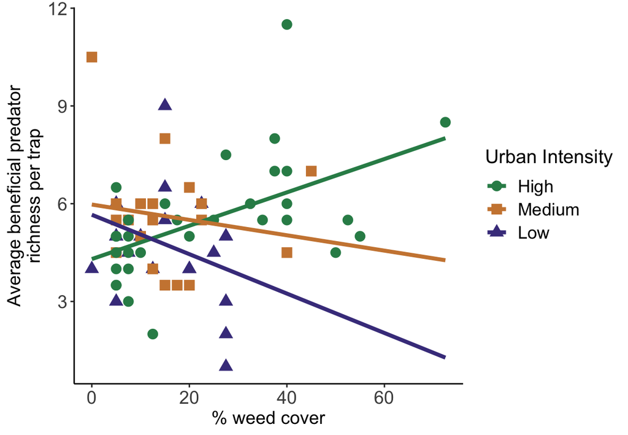

The results of our plant community survey are interesting! Here, we see different relationships between the area of weeds surrounding the crops and the diversity of arthropods that we found in our traps based on the Urban Intensity category of the farm:

1. On farms in the High Urban Intensity category, higher abundances of weeds relates to a higher diversity of beneficial arthropod predators.
2. On farms in the Medium and Low Urban Intensity categories, higher abundances of weeds relates to a lower diversity of beneficial arthropod predators.

We believe these patterns are due to the presence of different weed species on urban farms (High Urban Intensity) compared to non-urban farms (Medium and Low Urban Intensity), which may be a result of different weed management practices, soil nutrients, or other factors between these categories of farms. We think that the weeds species on High Urban Intensity farms may provide better habitat and/or nutrient resources for these beneficial arthropod predators, which promotes higher arthropod predator diversity.

### The average **abundance** of beneficial arthropod predators in the presence and absence of plastic mulch across all farms:

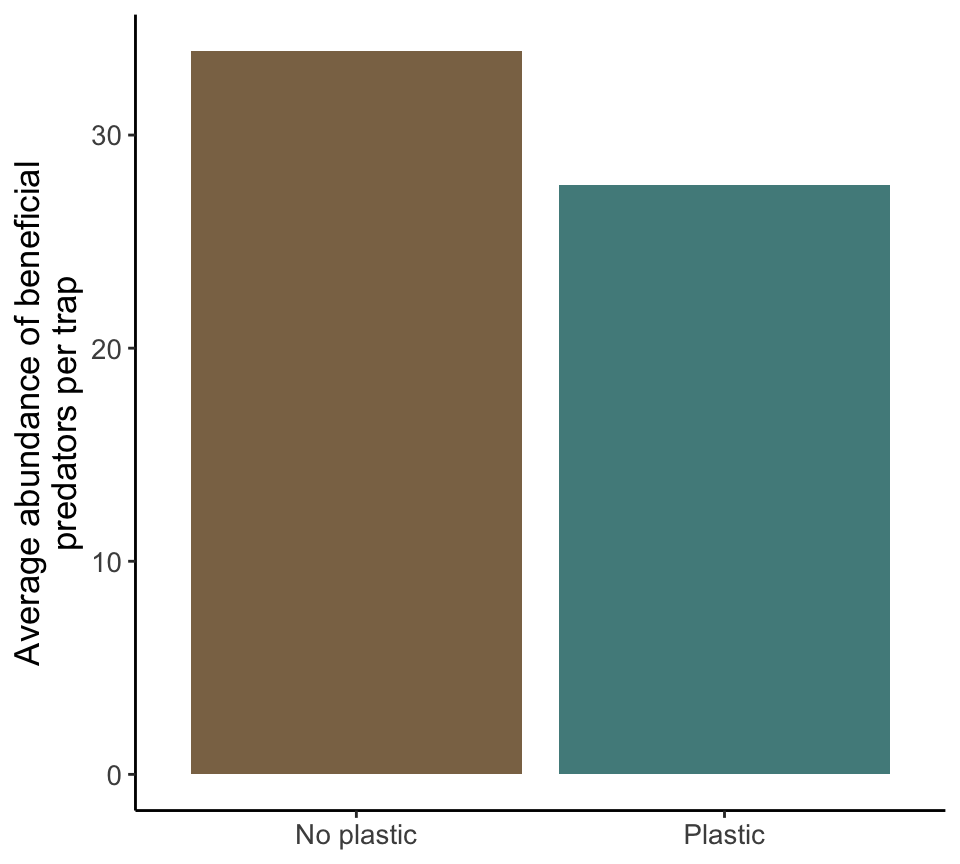

Here, we see that the presence of plastic mulch around the crops that we surveyed relates to a statistically significant decrease in the amount of beneficial arthropod predators that we collected.

### The average **richness (number of types)** of beneficial arthropod predators in the presence and absence of plastic mulch across all farms:

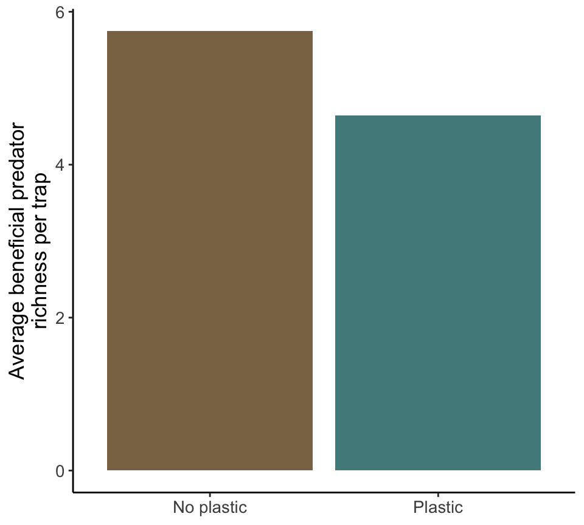

Here, we see that the presence of plastic mulch around the crops that we surveyed relates to a statistically significant decrease in the diversity of beneficial arthropod predators that we collected.

This report was created by Dan Turner and Dr. Jocelyn Behm at the Integrative Ecology at Temple University (http://www.iecolab.org/).